# 2026-04-21_hw04

Chris

2026-04-21

The project is on GitHub: https://github.com/ChrisW12372/2026-04-21_p8106-hw04.git

```r
library(tidyverse)
library(tidymodels)
library(caret)
library(rpart)
library(rpart.plot)
library(party)
library(partykit)
library(randomForest)
library(ranger)
library(gbm)
library(xgboost)

set.seed(202604)
```

# 1 Question One

```r
df_college <- read.csv("data/College.csv", row.names = 1) |>
  janitor::clean_names()
```

## 1.1 Part I

### 1.1.1 Fit the Model

```r
set.seed(202604)
data_split <- initial_split(df_college, prop = 0.8)

df_col_train <- training(data_split)
df_col_test <- testing(data_split)
```

```r
set.seed(202604)
tree1 <- rpart(
  outstate ~ ., data = df_col_train,
  control = rpart.control(cp = 0.005)
)

cpTable1 <- tree1$cptable
print(cpTable1)
```

```
##             CP nsplit rel error    xerror       xstd
## 1  0.513231601      0 1.0000000 1.0043483 0.05694259
## 2  0.095506855      1 0.4867684 0.5015094 0.03258904
## 3  0.044930031      2 0.3912615 0.4446780 0.03182371
## 4  0.036275441      3 0.3463315 0.4462888 0.03547997
## 5  0.023244525      4 0.3100561 0.4267958 0.03462264
## 6  0.016225674      5 0.2868115 0.4037921 0.03161259
## 7  0.015980179      6 0.2705859 0.3961102 0.03157220
## 8  0.013732407      7 0.2546057 0.3920722 0.03168310
## 9  0.009061868      8 0.2408733 0.3749114 0.03181175
## 10 0.008871188      9 0.2318114 0.3708588 0.03078982
## 11 0.008293686     10 0.2229402 0.3655429 0.03059469
## 12 0.005774182     11 0.2146465 0.3705458 0.03109923
## 13 0.005723490     12 0.2088724 0.3630799 0.03083692
## 14 0.005435412     13 0.2031489 0.3641175 0.03089899
## 15 0.005065134     15 0.1922781 0.3636800 0.03088295
## 16 0.005000000     16 0.1872129 0.3654078 0.03091312
```

### 1.1.2 xerror

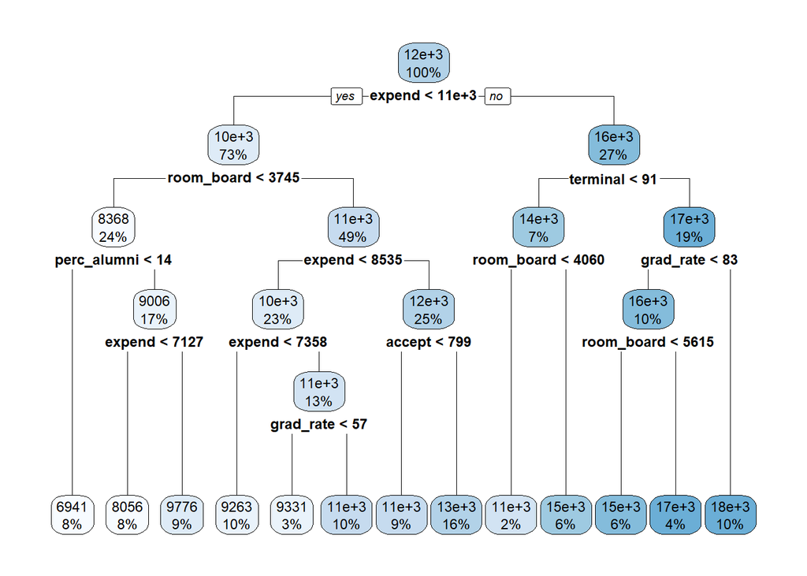

```r
set.seed(202604)
min_err1 <- which.min(cpTable1[, "xerror"])
tree2 <- prune(tree1, cp = cpTable1[min_err1, "CP"])
rpart.plot(tree2)
```

```r
tree_pred <- predict(tree2, newdata = df_col_test)

test_mse <- mean((tree_pred - df_col_test$outstate)^2)
test_rmse <- sqrt(test_mse)

test_mse
```

```
## [1] 4480294
```

```r
test_rmse
```

```
## [1] 2116.67
```

### 1.1.3 1se rule

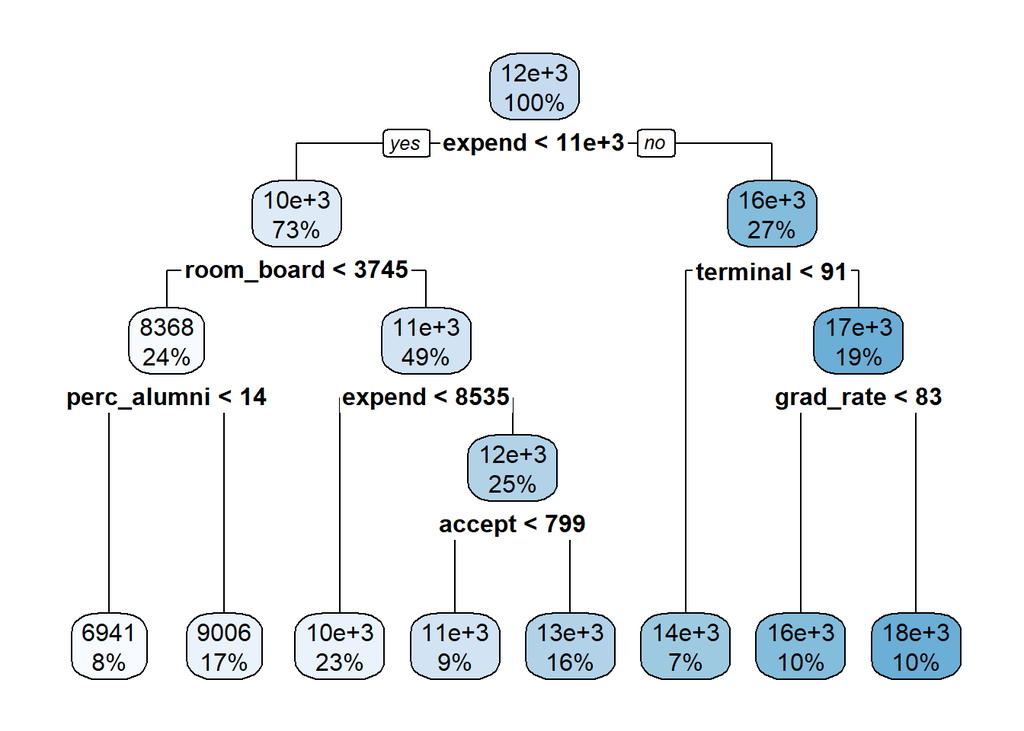

```r
set.seed(202604)
min_row <- which.min(cpTable1[, "xerror"])
xerror_min <- cpTable1[min_row, "xerror"]
xstd_min   <- cpTable1[min_row, "xstd"]

threshold_1se <- xerror_min + xstd_min
candidate_rows <- which(cpTable1[, "xerror"] <= threshold_1se)
row_1se <- candidate_rows[1]

cp_1se <- cpTable1[row_1se, "CP"]

tree_1se <- prune(tree1, cp = cp_1se)

rpart.plot(tree_1se)
```

```r
tree_pred <- predict(tree_1se, newdata = df_col_test)

test_mse <- mean((tree_pred - df_col_test$outstate)^2)
test_rmse <- sqrt(test_mse)

test_mse
```

```
## [1] 4343946
```

```r
test_rmse
```

```
## [1] 2084.214
```

## 1.2 Part II

### 1.2.1 Fit the Model

```r
set.seed(202604)
ctrl <- trainControl(method = "cv", number = 10)
rf_grid <- expand.grid(mtry = 1:(ncol(df_col_train) - 1),
                       splitrule = "variance",
                       min.node.size = 1:6)

fit_rf <- train(outstate ~ .,
                data = df_col_train,
                method = "ranger",
                tuneGrid = rf_grid,
                trControl = ctrl,
                importance = "permutation")
```

### 1.2.2 Variable Importance

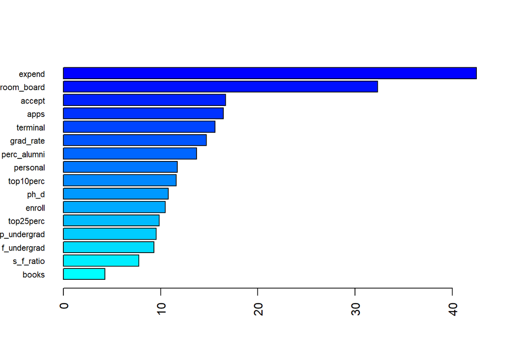

```r
set.seed(202604)
fit_rf_final <- ranger(
  outstate ~ .,
  data = df_col_train,
  mtry = fit_rf$bestTune[[1]],
  splitrule = "variance",
  min.node.size = fit_rf$bestTune[[3]],
  importance = "permutation",
  scale.permutation.importance = TRUE
)

barplot(
  sort(ranger::importance(fit_rf_final), decreasing = FALSE),
  las = 2,
  horiz = TRUE,
  cex.names = 0.7,
  col = colorRampPalette(colors = c("cyan", "blue"))(length(ranger::importance(fit_rf_final)))
)
```

### 1.2.3 Test Error

```r
rf_pred <- predict(fit_rf_final, data = df_col_test)$predictions
test_mse <- mean((rf_pred - df_col_test$outstate)^2)
test_rmse <- sqrt(test_mse)
test_mse
```

```
## [1] 3509856
```

```r
test_rmse
```

```
## [1] 1873.461
```

- The variable importance plot from the random forest model shows that “expend” is the most important predictor of “Outstate”, followed by “room_board”. Other influential variables include “accept, apps, terminal, and grad_rate”. In contrast, variables such as “books” and “s_f_ratio” appear to contribute relatively little to prediction accuracy.
- Using the final random forest model, the test mean squared error (MSE) is 3,509,856, corresponding to a test root mean squared error (RMSE) of 1,873.461.

## 1.3 Part III

```r
gbm_grid <- expand.grid(
  n.trees = c(100, 200, 500, 1000, 2000, 5000),
  interaction.depth = 1:4,
  shrinkage = c(0.005, 0.01, 0.05),
  n.minobsinnode = c(5, 10)
)
```

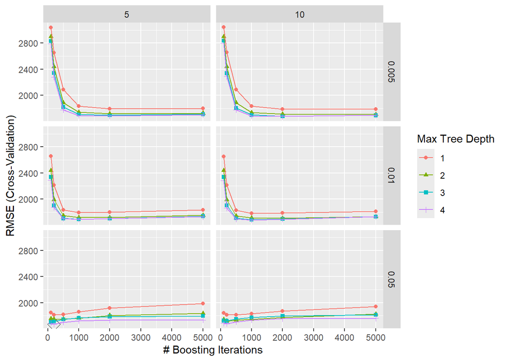

```r
set.seed(202604)

fit_gbm <- train(
  outstate ~ .,
  data = df_col_train,
  method = "gbm",
  distribution = "gaussian",
  trControl = ctrl,
  tuneGrid = gbm_grid,
  verbose = FALSE
)

ggplot(fit_gbm, highlight = TRUE)
```

```r
fit_gbm$bestTune
```

```
##     n.trees interaction.depth shrinkage n.minobsinnode
## 134     200                 4      0.05              5
```

```r
gbm_imp <- summary(fit_gbm$finalModel, plotit = FALSE)
gbm_imp
```

```
##                     var   rel.inf
## expend           expend 50.752589
## room_board   room_board 10.818381
## terminal       terminal  5.885538
## perc_alumni perc_alumni  4.202443
## grad_rate     grad_rate  4.115682
## apps               apps  3.874135
## personal       personal  3.216638
## top10perc     top10perc  3.062111
## accept           accept  2.729788
## p_undergrad p_undergrad  2.285932
## f_undergrad f_undergrad  1.885289
## s_f_ratio     s_f_ratio  1.803650
## ph_d               ph_d  1.729103
## top25perc     top25perc  1.329975
## books             books  1.225856
## enroll           enroll  1.082891
```

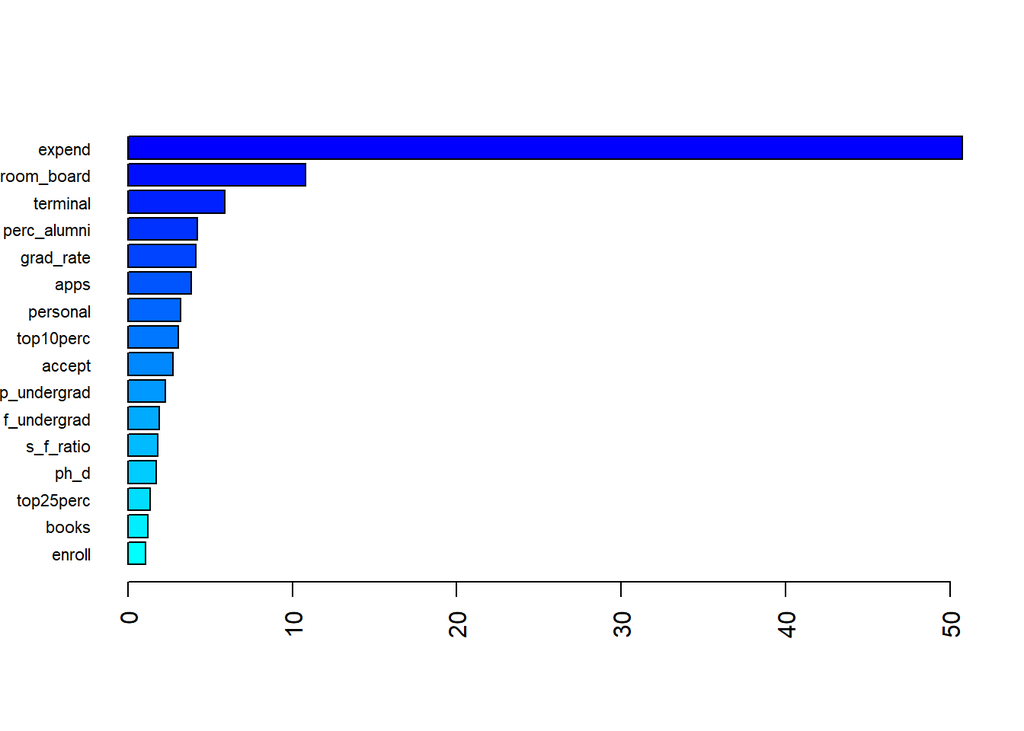

```r
barplot(
  sort(gbm_imp$rel.inf, decreasing = FALSE),
  names.arg = gbm_imp$var[order(gbm_imp$rel.inf)],
  las = 2,
  horiz = TRUE,
  cex.names = 0.7,
  col = colorRampPalette(colors = c("cyan", "blue"))(nrow(gbm_imp))
)
```

### 1.3.1 Test Error

```r
gbm_pred <- predict(fit_gbm, newdata = df_col_test)

test_mse <- mean((gbm_pred - df_col_test$outstate)^2)
test_rmse <- sqrt(test_mse)

test_mse
```

```
## [1] 3576395
```

```r
test_rmse
```

```
## [1] 1891.136
```

- The variable importance plot from the boosting model shows that expend is by far the most important predictor of outstate. The second most important variable is room_board, followed by terminal, perc_alumni, grad_rate, and apps. In contrast, variables such as books, enroll, and top25perc appear to contribute relatively little to prediction accuracy.
- Using the fitted boosting model, I predicted outstate for the test data. The resulting test mean squared error (MSE) was 3,576,395, corresponding to a test root mean squared error (RMSE) of 1,891.136. This means that the model’s predictions differ from the observed out-of-state tuition by about 1,891 dollars on average in the test set.

# 2 Question Two

```r
set.seed(202604)
df_auto <- read_csv("data/auto.csv") |>
  janitor::clean_names() |>
  mutate(mpg_cat = factor(mpg_cat), origin = factor(origin))
data_split_auto <- initial_split(df_auto, prop = 0.7)

df_auto_train <- training(data_split_auto)
df_auto_test <- testing(data_split_auto)
```

## 2.1 Part I

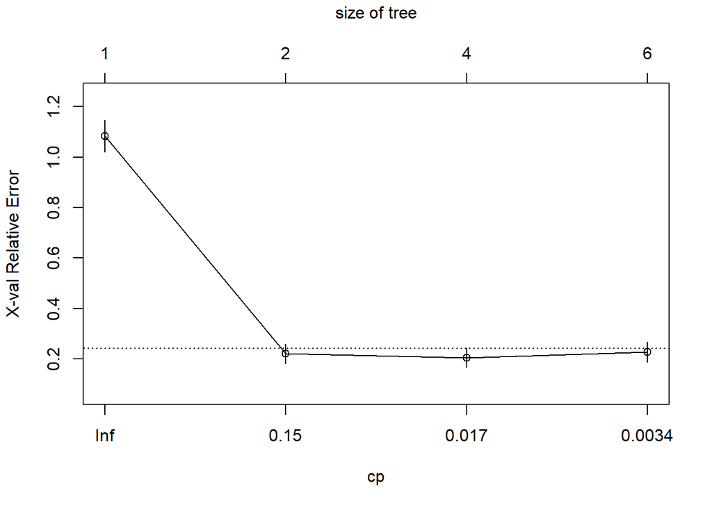

```r
set.seed(202604)
tree1 <- rpart(
  mpg_cat ~ .,
  data = df_auto_train,
  method = "class",
  control = rpart.control(cp = 0.001)
)

plotcp(tree1)
```

```r
printcp(tree1)
```

```
##
## Classification tree:
## rpart(formula = mpg_cat ~ ., data = df_auto_train, method = "class",
##     control = rpart.control(cp = 0.001))
##
## Variables actually used in tree construction:
## [1] displacement weight       year
##
## Root node error: 132/274 = 0.48175
##
## n= 274
##
##         CP nsplit rel error  xerror     xstd
## 1 0.810606      0   1.00000 1.08333 0.062640
## 2 0.026515      1   0.18939 0.21970 0.038577
## 3 0.011364      3   0.13636 0.20455 0.037375
## 4 0.001000      5   0.11364 0.22727 0.039157
```

```r
cpTable2 <- tree1$cptable
cpTable2
```

```
##           CP nsplit rel error    xerror       xstd
## 1 0.81060606      0 1.0000000 1.0833333 0.06264039
## 2 0.02651515      1 0.1893939 0.2196970 0.03857739
## 3 0.01136364      3 0.1363636 0.2045455 0.03737500
## 4 0.00100000      5 0.1136364 0.2272727 0.03915672
```

```r
min_row <- which.min(cpTable2[, "xerror"])
cp_min <- cpTable2[min_row, "CP"]
nsplit_min <- cpTable2[min_row, "nsplit"]

cp_min
```

```
## [1] 0.01136364
```

```r
nsplit_min
```

```
## [1] 3
```

```r
cpTable2[min_row, ]
```

```
##         CP     nsplit  rel error     xerror       xstd
## 0.01136364 3.00000000 0.13636364 0.20454545 0.03737500
```

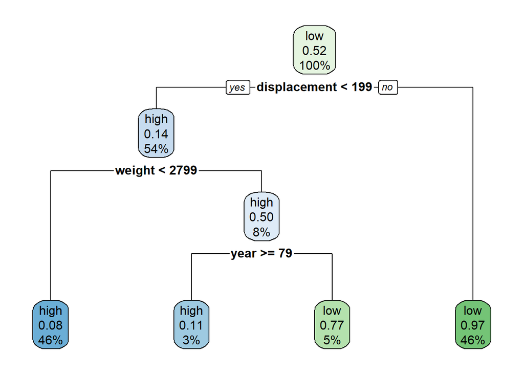

```r
tree_min <- prune(tree1, cp = cp_min)
rpart.plot(tree_min)
```

```r
set.seed(202604)
xerror_min <- cpTable2[min_row, "xerror"]
xstd_min   <- cpTable2[min_row, "xstd"]

threshold_1se <- xerror_min + xstd_min

candidate_rows <- which(cpTable2[, "xerror"] <= threshold_1se)

row_1se <- candidate_rows[1]
cp_1se <- cpTable2[row_1se, "CP"]
nsplit_1se <- cpTable2[row_1se, "nsplit"]

cp_1se
```

```
## [1] 0.02651515
```

```r
nsplit_1se
```

```
## [1] 1
```

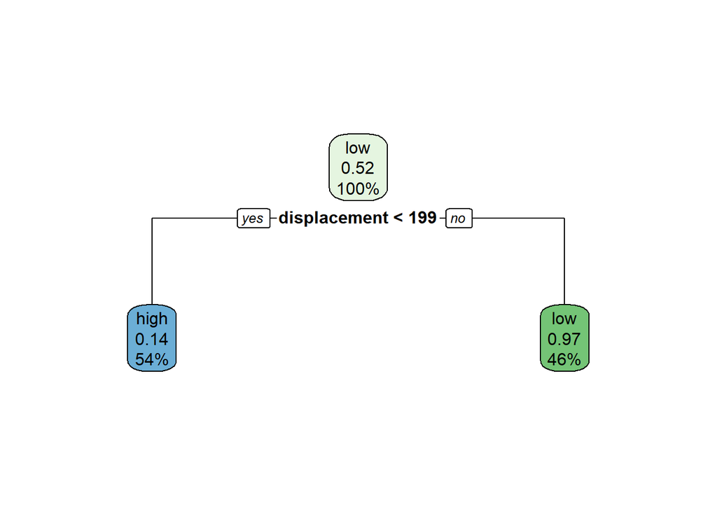

```r
tree_1se <- prune(tree1, cp = cp_1se)
rpart.plot(tree_1se)
```

## 2.2 Part II

```r
gbm_grid2 <- expand.grid(
  n.trees = c(100, 200, 500, 1000, 2000),
  interaction.depth = 1:4,
  shrinkage = c(0.005, 0.01, 0.05),
  n.minobsinnode = c(5, 10)
)
```

```r
set.seed(202604)

fit_gbm2 <- train(
  mpg_cat ~ .,
  data = df_auto_train,
  method = "gbm",
  trControl = ctrl,
  tuneGrid = gbm_grid2,
  verbose = FALSE
)
```

```r
# best tuning parameters
fit_gbm2$bestTune
```

```
##    n.trees interaction.depth shrinkage n.minobsinnode
## 97     200                 2      0.05             10
```

```r
# all tuning results
fit_gbm2$results
```

```
##     shrinkage interaction.depth n.minobsinnode n.trees  Accuracy     Kappa
## 1       0.005                 1              5     100 0.8977240 0.7956184
## 6       0.005                 1             10     100 0.8975917 0.7953147
## 41      0.010                 1              5     100 0.9049991 0.8101178
## 46      0.010                 1             10     100 0.9014277 0.8029750
## 81      0.050                 1              5     100 0.9233853 0.8466778
## 86      0.050                 1             10     100 0.9196816 0.8394020
## 11      0.005                 2              5     100 0.9159779 0.8321279
## 16      0.005                 2             10     100 0.9088351 0.8177689
## 51      0.010                 2              5     100 0.9232531 0.8467085
## 56      0.010                 2             10     100 0.9195494 0.8392708
## 91      0.050                 2              5     100 0.9196816 0.8392394
## 96      0.050                 2             10     100 0.9159779 0.8316776
## 21      0.005                 3              5     100 0.9121419 0.8243133
## 26      0.005                 3             10     100 0.9159779 0.8319643
```

[output cut: 227 more lines]

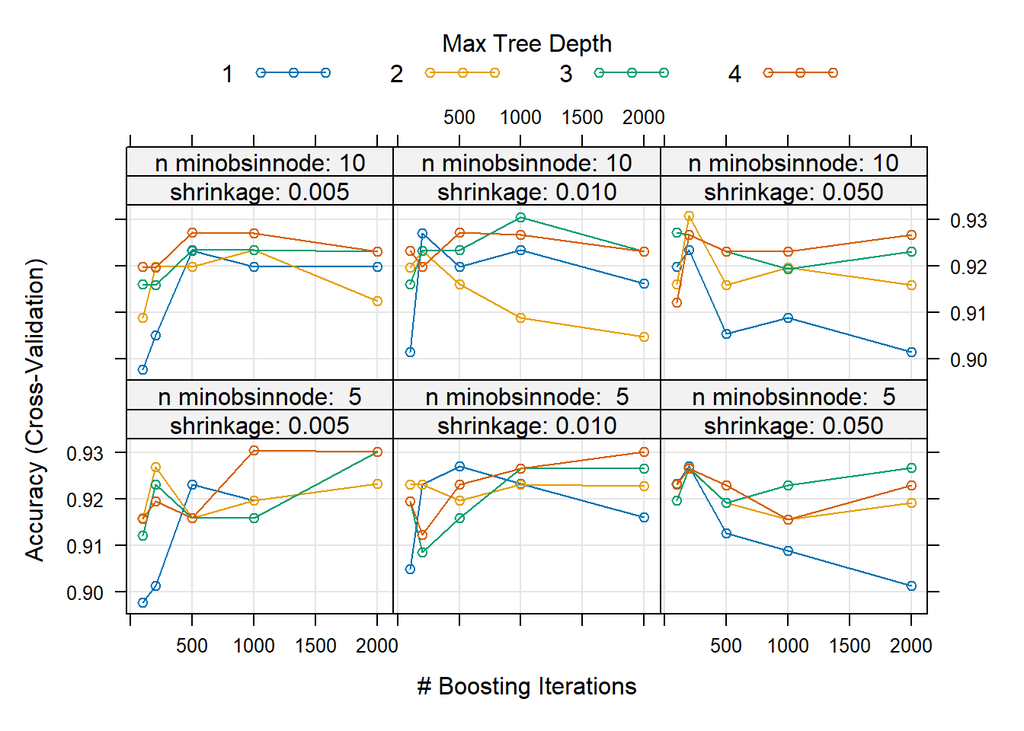

```r
# optional tuning plot
plot(fit_gbm2)
```

```r
gbm_imp <- summary(fit_gbm2$finalModel, plotit = FALSE)
gbm_imp
```

```
##                       var     rel.inf
## displacement displacement 48.19802320
## weight             weight 23.62698977
## year                 year 11.49414703
## horsepower     horsepower 10.44143207
## acceleration acceleration  3.74495327
## cylinders       cylinders  2.40600543
## origin2           origin2  0.08844925
## origin3           origin3  0.00000000
```

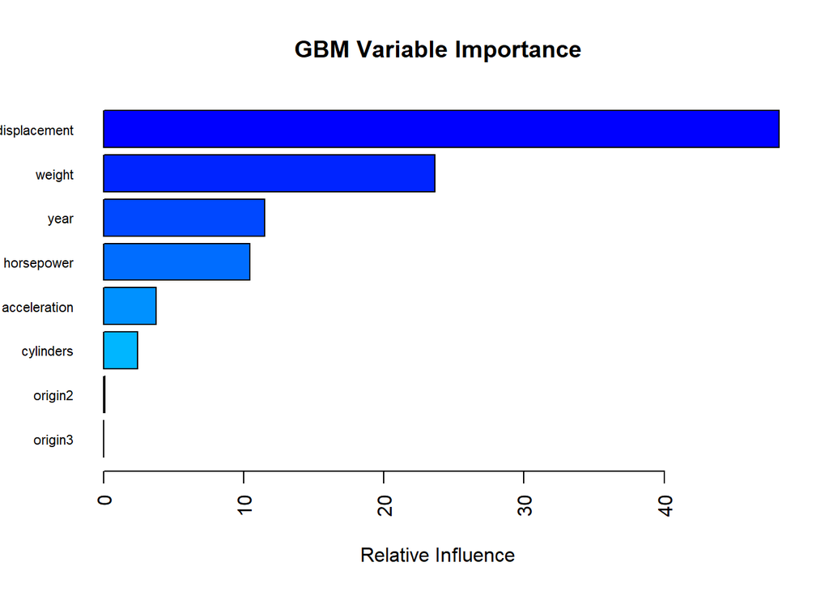

```r
gbm_imp_sorted <- gbm_imp[order(gbm_imp$rel.inf), ]

barplot(
  gbm_imp_sorted$rel.inf,
  names.arg = gbm_imp_sorted$var,
  las = 2,
  horiz = TRUE,
  cex.names = 0.7,
  col = colorRampPalette(c("cyan", "blue"))(nrow(gbm_imp_sorted)),
  xlab = "Relative Influence",
  main = "GBM Variable Importance"
)
```

```r
gbm_pred_class <- predict(fit_gbm2, newdata = df_auto_test)

test_acc <- mean(gbm_pred_class == df_auto_test$mpg_cat)
test_err <- mean(gbm_pred_class != df_auto_test$mpg_cat)

test_acc
```

```
## [1] 0.8983051
```

```r
test_err
```

```
## [1] 0.1016949
```

```r
confusionMatrix(gbm_pred_class, df_auto_test$mpg_cat)
```

```
## Confusion Matrix and Statistics
##
##           Reference
## Prediction high low
##       high   59   7
##       low     5  47
##
##                Accuracy : 0.8983
##                  95% CI : (0.8291, 0.9463)
##     No Information Rate : 0.5424
##     P-Value [Acc > NIR] : <2e-16
##
##                   Kappa : 0.7945
##
##  Mcnemar's Test P-Value : 0.7728
##
##             Sensitivity : 0.9219
##             Specificity : 0.8704
##          Pos Pred Value : 0.8939
##          Neg Pred Value : 0.9038
##              Prevalence : 0.5424
##          Detection Rate : 0.5000
##    Detection Prevalence : 0.5593
##       Balanced Accuracy : 0.8961
##
##        'Positive' Class : high
##
```

- I fit a boosting model on the training data and evaluated its predictive performance on the test set. The test accuracy was 0.8983, corresponding to a test misclassification error of 0.1017. This indicates that the boosting model performed very well on the test data, correctly classifying about 89.83% of the observations.
- Based on the variable importance plot, displacement is the most important predictor of mpg_cat, followed by weight, year, and horsepower. In contrast, variables such as origin and cylinders appear to have relatively smaller contributions. Overall, the results suggest that engine size and vehicle size characteristics are the most influential factors in predicting fuel-efficiency category.